# Final project part 3

Alaa Alghwiri

2025-04-21

# 1. Set up the environment

```r
easypackages::libraries("here", "tidyverse", "viridisLite", "ggdist",
                        "distributional", "ggridges", "ggpubr", "yardstick",
                        "rstanarm", "caret")
```

```
## here() starts at /Users/alghwiri/Library/CloudStorage/OneDrive-UniversityofPittsburgh/Drive Back-up/Acadmics/HDS masters/Taken Courses/Machine Learning
```

[output not shown]

# 2. Data Preparation

Here, we load the data same as in Part 1 and perform normalization on continuous inputs:

```r
df_orig <- read_csv(here("Final project/Submit/paint_train_split.csv"))
```

```
## ──────────────────────────────────────────────────────── Delimiter: "," chr
## (2): Lightness, Saturation dbl (7): ...1, R, G, B, Hue, response, outcome
```

```r
df <- df_orig %>%
  select(R, G, B, Lightness, Saturation, Hue, outcome) %>%
  mutate_at(c("R", "G", "B", "Hue"), ~(scale(.) %>% as.vector))

df %>% summary()
```

```
##        R                 G                 B            Lightness
##  Min.   :-3.2078   Min.   :-2.3696   Min.   :-2.0652   Length:751
##  1st Qu.:-0.6307   1st Qu.:-0.7562   1st Qu.:-0.8684   Class :character
##  Median : 0.3160   Median : 0.2359   Median : 0.1640   Mode  :character
##  Mean   : 0.0000   Mean   : 0.0000   Mean   : 0.0000
##  3rd Qu.: 0.8068   3rd Qu.: 0.9073   3rd Qu.: 0.9315
##  Max.   : 1.2627   Max.   : 1.2981   Max.   : 1.4248
##   Saturation             Hue              outcome
##  Length:751         Min.   :-1.65312   Min.   :0.0000
##  Class :character   1st Qu.:-0.85710   1st Qu.:0.0000
##  Mode  :character   Median :-0.06108   Median :0.0000
##                     Mean   : 0.00000   Mean   :0.2344
##                     3rd Qu.: 0.83444   3rd Qu.:0.0000
##                     Max.   : 1.82947   Max.   :1.0000
```

Also, for validation purposes, we split the data into training and testing sets:

```r
set.seed(0)
train_id <- sample(1:nrow(df), size = floor(0.8 * nrow(df)))
df_train <- df %>% slice(train_id)
df_test <- df %>% slice(-train_id)
```

# 3. Generalized Linear Models

## 3.1 Fitting Linear Models

We declare and train the 10 models, 7 described in the instructions. Due to the random nature in this process, we set the randomizer seed to 0 for all chunks below:

```r
mod01 <- glm(outcome ~ 1, family = "binomial", data = df_train) # Intercept only
mod02 <- glm(outcome ~ Lightness + Saturation, family = "binomial", data = df_train) # Categorical variables only
mod03 <- glm(outcome ~ R + G + B + Hue, family = "binomial", data = df_train) # Continuous variables only
mod04 <- glm(outcome ~ R + G + B + Hue + Lightness + Saturation, family = "binomial", data = df_train) # All categorical and continuous variables
mod05 <- glm(outcome ~ (R + G + B + Hue) * (Lightness + Saturation), family = "binomial", data = df_train) # Interaction of categorical inputs with continuous inputs main effects
mod06 <- glm(outcome ~ (R + G + B + Hue)^2 + Lightness + Saturation, family = "binomial", data = df_train) # Categorical inputs, main effect and all pairwise interactions
mod07 <- glm(outcome ~ (R + G + B + Hue)^2 * (Lightness + Saturation), family = "binomial", data = df_train) # Interaction of categorical inputs with main effect and all pairwise interactions
```

And the 3 with non-linear basis functions. We have established in Part 1 that the relationship between Hue (H) and y is probably quadratic. Since we have established RGB data are highly correlated, we include pair-wise interactions between them:

```r
mod08 <- glm(outcome ~ ( (R + G + B)^2 + splines::ns(Hue, 2) ) * (Lightness + Saturation), family = "binomial", data = df_train) # Non linear basis functions
mod09 <- glm(outcome ~ (R + G + B)^2 * splines::ns(Hue, 2) + (Lightness + Saturation), family = "binomial", data = df_train)
```

```
## Warning: glm.fit: fitted probabilities numerically 0 or 1 occurred
```

```r
mod10 <- glm(outcome ~ (R + G + B)^2 + splines::ns(Hue, 2) * (Lightness * Saturation), family = "binomial", data = df_train)
```

```
## Warning: glm.fit: algorithm did not converge
## Warning: glm.fit: fitted probabilities numerically 0 or 1 occurred
```

Here, the model fitting process gives the warning “glm.fit: fitted probabilities numerically 0 or 1 occurred”, which, according to search results, is caused by outlier data with probabilities of 0 or 1.

## 3.2 Model Evaluation

First, we provide a view of common metrics, including the log-likelihood, AIC and BIC.

```r
models <- list(mod01, mod02, mod03, mod04, mod05, mod06, mod07, mod08, mod09, mod10)
metrics <- models %>%
  purrr::map_df(broom::glance) %>%
  mutate(model_name = 1:10)
```

For log likelihood:

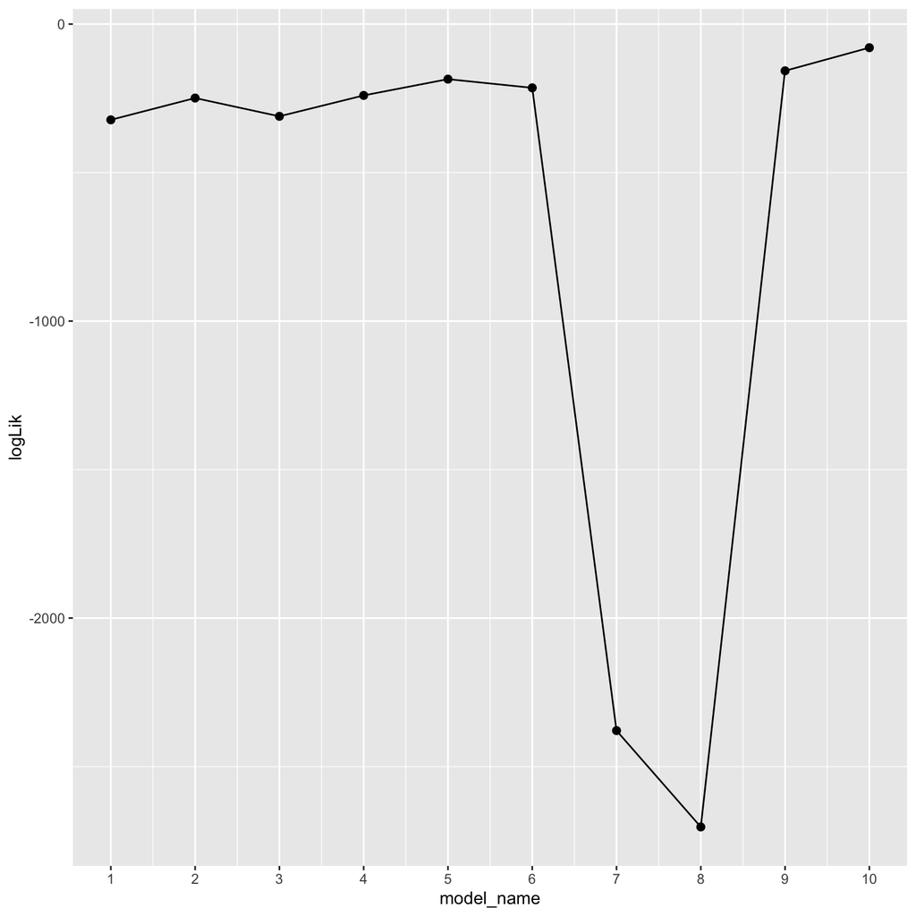

```r
metrics %>%
  ggplot(mapping = aes(x = model_name, y = logLik)) +
  geom_line() + geom_point(size = 2) +
  scale_x_continuous(breaks = round(seq(1, 10, by = 1), 1))
```

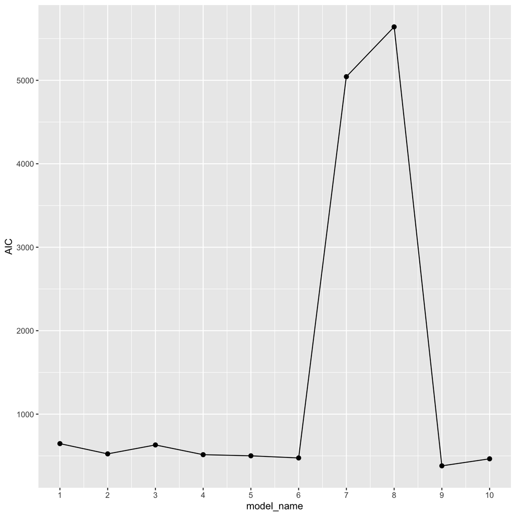

```r
metrics %>%
  ggplot(mapping = aes(x = model_name, y = AIC)) +
  geom_line() + geom_point(size = 2) +
  scale_x_continuous(breaks = round(seq(1, 10, by = 1), 1))
```

More importantly, we also include BIC in determining the best model since it is a training set only metric, and more conservative than AIC:

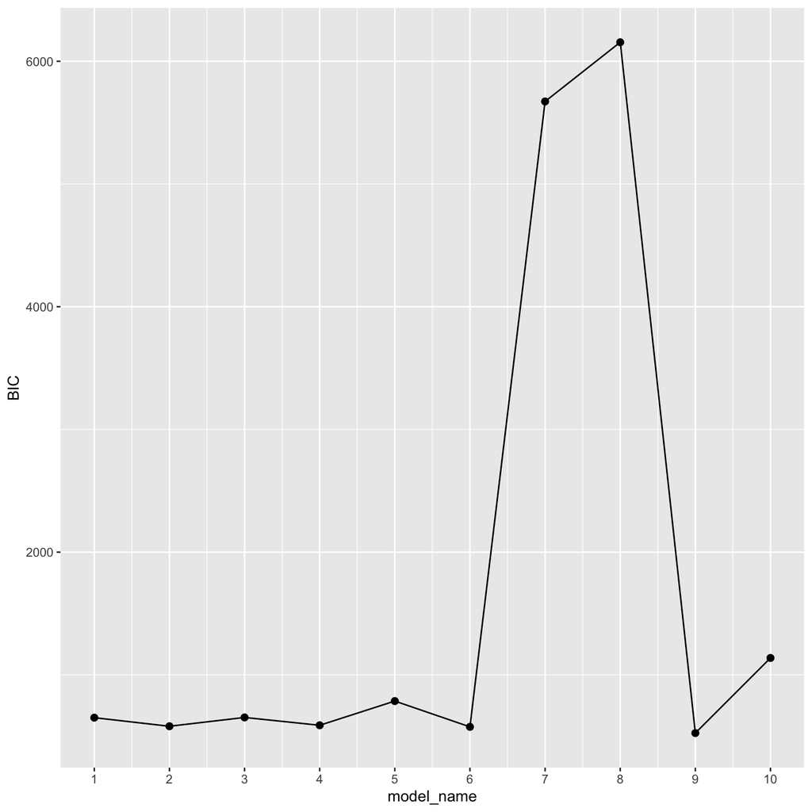

```r
metrics %>%
  ggplot(mapping = aes(x = model_name, y = BIC)) +
  geom_line() + geom_point(size = 2) +
  scale_x_continuous(breaks = round(seq(1, 10, by = 1), 1))
```

We also show the AIC and BIC values since the minimal value is hard to determine from the figure

```r
metrics[order(metrics$AIC),] %>% select("model_name", "AIC")
```

```
## # A tibble: 10 × 2
##    model_name   AIC
##         <int> <dbl>
##  1          9  381.
##  2         10  465.
##  3          6  475.
##  4          5  501.
##  5          4  514.
##  6          2  524.
##  7          3  631.
##  8          1  647.
##  9          7 5044.
## 10          8 5641.
```

```r
metrics[order(metrics$BIC),] %>% select("model_name", "BIC")
```

```
## # A tibble: 10 × 2
##    model_name   BIC
##         <int> <dbl>
##  1          9  526.
##  2          6  576.
##  3          2  581.
##  4          4  589.
##  5          1  651.
##  6          3  653.
##  7          5  786.
##  8         10 1138.
##  9          7 5673.
## 10          8 6155.
```

```r
pred <- function(mod, test_data, y)
{
  pred_test <- data.frame(prob = predict(mod, newdata = test_data, type="response")) %>%
    mutate(class = ifelse(prob > 0.5, 'event', 'non_event'),
           class = factor(class, levels = c('event', 'non_event'))) %>%
    dplyr::select(all_of("class")) %>% pull()

  y_test <- test_data %>%
    mutate(outcome = ifelse(outcome == 1, 'event', 'non_event'),
           outcome = factor(outcome, levels = c('event', 'non_event'))) %>%
    dplyr::select(all_of(y)) %>% pull()

  test_metrics <- tibble::tibble(
    acc = accuracy_vec(y_test, pred_test)
  )
  test_metrics
}

results <-
  purrr::map_df(models,
                pred,
                test_data = df_test,
                y = "outcome") %>%
  mutate(model_name = 1:10)
```

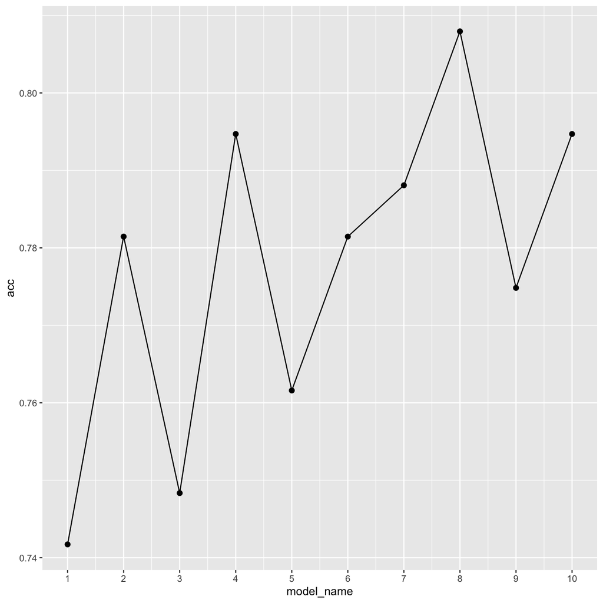

```r
results %>%
  ggplot(mapping = aes(x = model_name, y = acc)) +
  geom_line() + geom_point(size = 2) +
  scale_x_continuous(breaks = round(seq(1, 10, by = 1), 1))
```

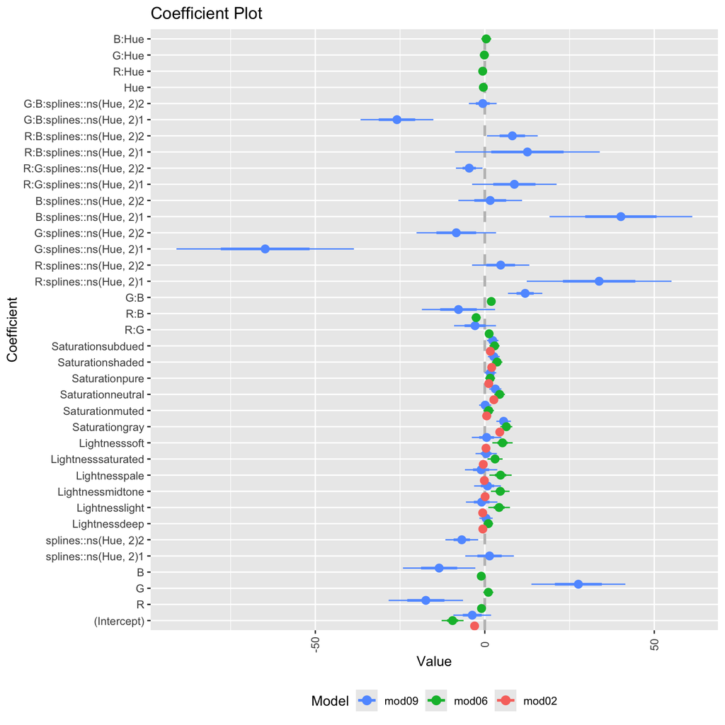

```r
coefplot::multiplot(mod09, mod06, mod02)
```

We provide some simple insights of the results:

For simpler variables shared by the 3 models, the coefficients identified by the 3 models are mostly close. However, more complex models (mod09) give a larger confidence interval.

For more complex variables, the variables are often not statistically significant. However, the coefficients identified by the 3 models differ.

By analyzing the coefficients, we conclude that the RGB data and their interaction with the Hue input are very important to the model. The interaction between 2 RGB data (e.g. G and B) is also influential. Categorical data, on the other hand, is much less important.

# 4. Bayesian Generalized Linear Models

## 4.1 Fitting Bayesian Linear models

```r
set.seed(0)
X09 <- model.matrix(outcome ~ (R + G + B)^2 * splines::ns(Hue, 2) + (Lightness + Saturation), family = "binomial", data = df)

info_09 <- list(
  yobs = df$outcome,
  design_matrix = X09,
  mu_beta = 0,
  tau_beta = 4
)
```

For model 06:

```r
set.seed(0)
X06 <- model.matrix(outcome ~ (R + G + B + Hue)^2 + Lightness + Saturation, family = "binomial", data = df)

info_06 <- list(
  yobs = df$outcome,
  design_matrix = X06,
  mu_beta = 0,
  tau_beta = 4
)
```

The following function calculates the log posterior:

```r
set.seed(0)
logistic_logpost <- function(unknowns, my_info)
{
  # extract the design matrix and assign to X
  X <- my_info$design_matrix

  # calculate the linear predictor
  eta <- as.vector(X %*% matrix(unknowns))

  # calculate the event probability
  mu <- boot::inv.logit(eta)

  # evaluate the log-likelihood
  log_lik <- sum(dbinom(x = my_info$yobs,
                        size = 1,
                        prob = mu,
                        log = TRUE))

  # evaluate the log-prior
  log_prior <- sum(dnorm(x = unknowns,
                         mean = my_info$mu_beta,
                         sd = my_info$tau_beta,
                         log = TRUE))

  # sum together
  log_lik + log_prior
}
```

And a function for the Laplace approximation which returns the object consisting of the posterior mode, posterior covariance matrix, and the log-evidence:

```r
set.seed(0)
my_laplace <- function(start_guess, logpost_func, ...)
{
  # code adapted from the `LearnBayes`` function `laplace()`
  fit <- optim(start_guess,
               logpost_func,
               gr = NULL,
               ...,
               method = "BFGS",
               hessian = TRUE,
               control = list(fnscale = -1, maxit = 5001))

  mode <- fit$par
  post_var_matrix <- -solve(fit$hessian)
  p <- length(mode)
  int <- p/2 * log(2 * pi) + 0.5 * log(det(post_var_matrix)) + logpost_func(mode, ...)
  # package all of the results into a list
  list(mode = mode,
       var_matrix = post_var_matrix,
       log_evidence = int,
       converge = ifelse(fit$convergence == 0,
                         "YES",
                         "NO"),
       iter_counts = as.numeric(fit$counts[1]))
}
```

Here, We execute the Laplace approximation for the 2 models with an initial guess of 0:

```r
set.seed(0)
laplace_09 <- my_laplace(rep(0, ncol(X09)), logistic_logpost, info_09)
laplace_06 <- my_laplace(rep(0, ncol(X06)), logistic_logpost, info_06)
```

To test whether the Bayesian Linear Models have converged:

```r
laplace_09$converge
```

```
## [1] "YES"
```

```r
laplace_06$converge
```

```
## [1] "YES"
```

## 4.2 Model Evaluation

To identify the best model, we use the log evidence as the metric:

```r
exp(laplace_09$log_evidence - laplace_06$log_evidence)
```

```
## [1] 3.124003e+16
```

Thus, we show that model 09 is the best model.

We also use the following function to visualize the coefficient posteriors.

```r
set.seed(0)
viz_post_coefs <- function(post_means, post_sds, xnames)
{
  tibble::tibble(
    mu = post_means,
    sd = post_sds,
    x = xnames
  ) %>%
    mutate(x = factor(x, levels = xnames)) %>%
    ggplot(mapping = aes(x = x)) +
    geom_hline(yintercept = 0, color = 'grey', linetype = 'dashed') +
    geom_point(mapping = aes(y = mu)) +
    geom_linerange(mapping = aes(ymin = mu - 2 * sd,
                                 ymax = mu + 2 * sd,
                                 group = x)) +
    labs(x = 'feature', y = 'coefficient value') +
    coord_flip() +
    theme_bw()
}
```

For model 09:

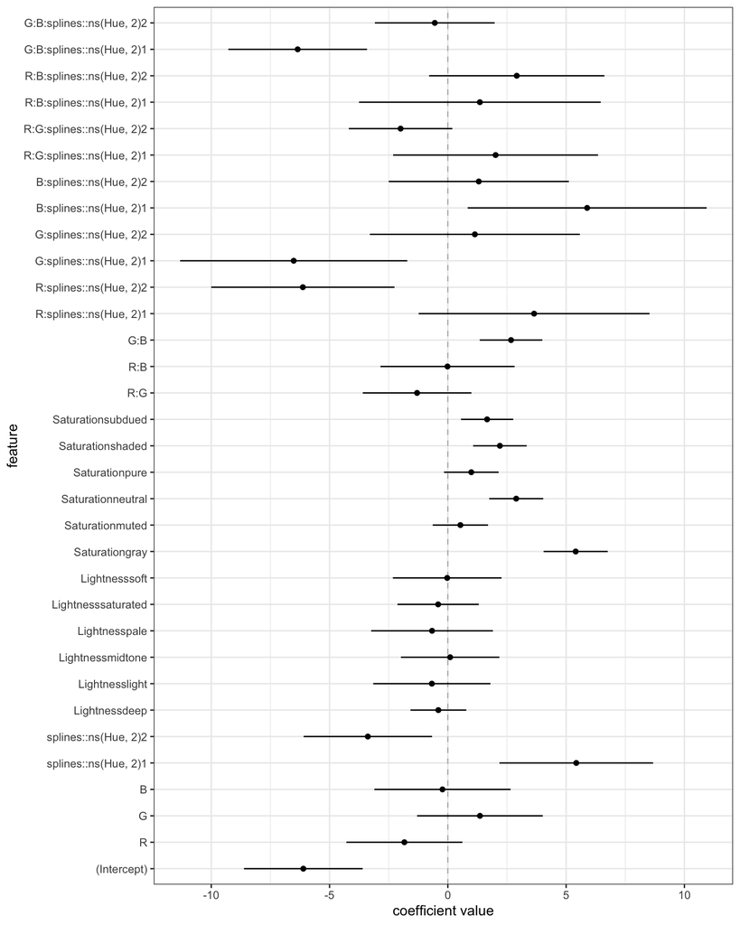

```r
post_means <- laplace_09$mode[1:ncol(X09)]
post_sd <- sqrt(diag(laplace_09$var_matrix)[1:ncol(X09)])
viz_post_coefs(post_means, post_sd, colnames(X09))
```

## 4.3 Best model and its Uncertainty

For the uncertainty on the unknown likelihood noise 𝜎, we first provide the posterior standard deviations for model 09:

For model 09:

```r
sqrt(diag(laplace_09$var_matrix))
```

```
##  [1] 1.2539878 1.2265604 1.3282728 1.4392047 1.6232783 1.3568984 0.5903975
##  [8] 1.2386662 1.0402043 1.2868648 0.8593914 1.1478019 0.6774711 0.5843286
## [15] 0.5707692 0.5776024 0.5661549 0.5520714 1.1486949 1.4178428 0.6610235
## [22] 2.4403709 1.9367915 2.4008363 2.2190850 2.5252008 1.9042268 2.1657101
## [29] 1.0937241 2.5543333 1.8524050 1.4664346 1.2651691
```

As shown above, the standard deviations are low. To further study the uncertainty on the unknown likelihood noise 𝜎, we would need to generate posterior samples to study the posterior distribution on different features. The samples are generated with the following function:

```r
generate_glm_post_samples <- function(mvn_result, num_samples)
{
  # specify the number of unknown beta parameters
  length_beta <- length(mvn_result$mode)

  # generate the random samples
  beta_samples <- MASS::mvrnorm(n = num_samples,
                                mu = mvn_result$mode,
                                Sigma = mvn_result$var_matrix)

  # change the data type and name
  beta_samples %>%
    as.data.frame() %>% tibble::as_tibble() %>%
    purrr::set_names(sprintf("beta_%02d", (1:length_beta) - 1))
}
```

```r
post_samples_09 <- generate_glm_post_samples(laplace_09, 1000)
```

Same as in Part 1, we transform the samples into a long format for visualization purposes:

```r
set.seed(0)
post_samples_09_long <- post_samples_09 %>%
  pivot_longer(colnames(post_samples_09)) %>%
  as.data.frame()
```

The posterior histograms for different samples are shown below:

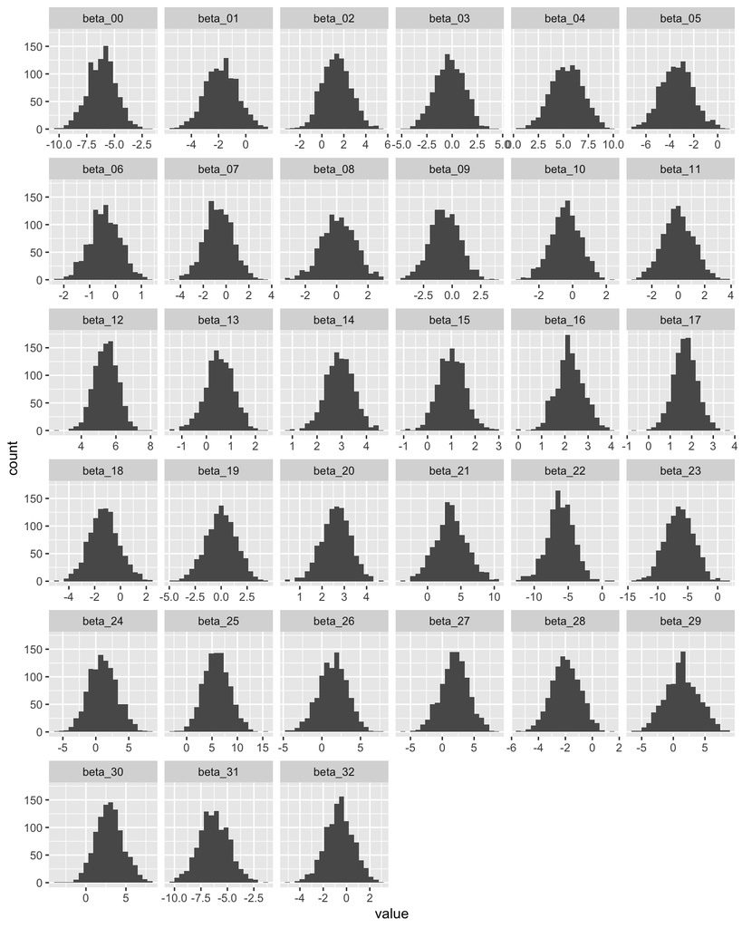

```r
post_samples_09_long %>%
  ggplot(mapping = aes(x = value)) +
  geom_histogram(bins = 20) +
  facet_wrap(~ name, scale = "free_x")
```

From the distributions, we show that the coefficient predictions distribution resembles a Gaussian distribution.

# 5. Linear Predictions

```r
set.seed(0)
viz_grid_R <- expand.grid(R = seq(min(df$R), max(df$R), length.out = 101),
                          G = mean(df$G),
                          B = mean(df$B),
                          Hue = mean(df$Hue),
                          Lightness = unique(df$Lightness),
                          Saturation = unique(df$Saturation),
                          KEEP.OUT.ATTRS = FALSE,
                          stringsAsFactors = FALSE) %>%
  as.data.frame() %>% tibble::as_tibble()
```

```r
set.seed(0)
viz_grid_G <- expand.grid(R = mean(df$R),
                          G = seq(min(df$G), max(df$G), length.out = 101),
                          B = mean(df$B),
                          Hue = mean(df$Hue),
                          Lightness = unique(df$Lightness),
                          Saturation = unique(df$Saturation),
                          KEEP.OUT.ATTRS = FALSE,
                          stringsAsFactors = FALSE) %>%
  as.data.frame() %>% tibble::as_tibble()
```

```r
set.seed(0)
viz_grid_B <- expand.grid(R = mean(df$R),
                          G = mean(df$G),
                          B = seq(min(df$B), max(df$B), length.out = 101),
                          Hue = mean(df$Hue),
                          Lightness = unique(df$Lightness),
                          Saturation = unique(df$Saturation),
                          KEEP.OUT.ATTRS = FALSE,
                          stringsAsFactors = FALSE) %>%
  as.data.frame() %>% tibble::as_tibble()
```

```r
set.seed(0)
viz_grid_H <- expand.grid(R = mean(df$R),
                          G = mean(df$G),
                          B = mean(df$B),
                          Hue = seq(min(df$Hue), max(df$Hue), length.out = 101),
                          Lightness = unique(df$Lightness),
                          Saturation = unique(df$Saturation),
                          KEEP.OUT.ATTRS = FALSE,
                          stringsAsFactors = FALSE) %>%
  as.data.frame() %>% tibble::as_tibble()
```

Using matrix math to calculate the posterior samples of the linear predictor

Summarizing the posterior predicted event probability with the posterior mean, as well as the 0.05 and 0.95 quantiles.

```r
set.seed(0)
post_logistic_pred_samples <- function(Xnew, Bmat)
{
  # calculate the linear predictor at all prediction points and posterior samples
  eta_mat <- Xnew %*% t(Bmat)
  # calculate the event probability
  mu_mat <- boot::inv.logit(eta_mat)
  # book keeping
  list(eta_mat = eta_mat, mu_mat = mu_mat)
}
```

```r
set.seed(0)
summarize_logistic_pred_from_laplace <- function(mvn_result, Xtest, num_samples)
{
  # generate posterior samples of the beta parameters
  betas <- generate_glm_post_samples(mvn_result, num_samples)

  # data type conversion
  betas <- as.matrix(betas)

  # make posterior predictions on the test set
  pred_test <- post_logistic_pred_samples(Xtest, betas)

  # calculate summary statistics on the posterior predicted probability
  # summarize over the posterior samples

  # posterior mean, should you summarize along rows (rowMeans) or
  # summarize down columns (colMeans) ???
  mu_avg <- rowMeans(pred_test$mu_mat)

  # posterior quantiles
  mu_q05 <- apply(pred_test$mu_mat, 1, stats::quantile, probs = 0.05)
  mu_q95 <- apply(pred_test$mu_mat, 1, stats::quantile, probs = 0.95)

  # book keeping
  tibble::tibble(
    mu_avg = mu_avg,
    mu_q05 = mu_q05,
    mu_q95 = mu_q95
  ) %>%
    tibble::rowid_to_column("pred_id")
}
```

Here, we make predictions with model 09. However, because we introduce the spline function for “Hue”, we cannot make predictions with only 1 Hue value (which is the case for viz_grid_R, viz_grid_G and viz_grid_B). Therefore, we only include the predictive trend of different values of Hue under different categorical inputs:

```r
set.seed(0)
Xviz_09_H <- model.matrix(~ (R + G + B)^2 * splines::ns(Hue, 2) + (Lightness + Saturation), family = "binomial", data = viz_grid_H)
post_pred_summary_09_H <- summarize_logistic_pred_from_laplace(laplace_09, Xviz_09_H, 1000)
```

The visualization for the predictive trend is shown below:

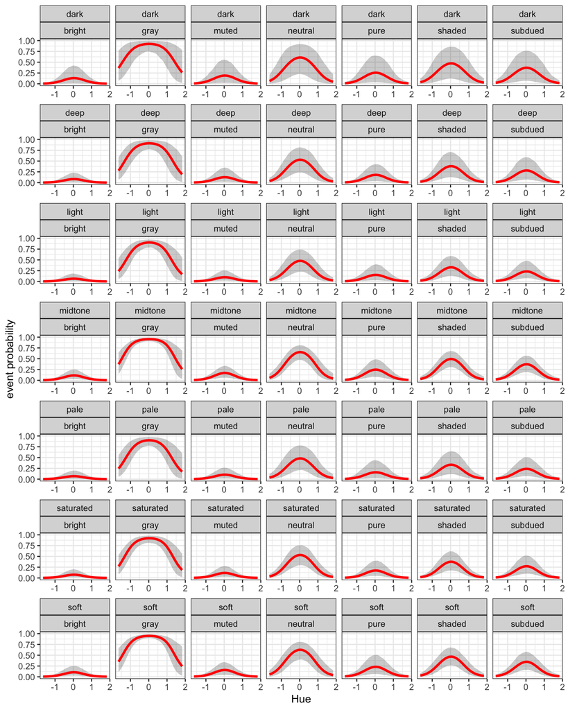

```r
set.seed(0)
post_pred_summary_09_H %>%
  left_join(viz_grid_H %>% tibble::rowid_to_column('pred_id'),
            by = 'pred_id') %>%
  ggplot(mapping = aes(x = Hue)) +
  geom_ribbon(mapping = aes(ymin = mu_q05, ymax = mu_q95), alpha = 0.25) +
  geom_line(mapping = aes(y = mu_avg), linewidth = 1.15, color = "red") +
  facet_wrap( ~ Lightness * Saturation, scales = "free_x") +
  labs(y = "event probability") +
  theme_bw()
```

For model 06, we include the trend for R, G, B and Hue:

```r
set.seed(0)
Xviz_06_R <- model.matrix(~ (R + G + B + Hue)^2 + Lightness + Saturation, family = "binomial", data = viz_grid_R)
Xviz_06_G <- model.matrix(~ (R + G + B + Hue)^2 + Lightness + Saturation, family = "binomial", data = viz_grid_G)
Xviz_06_B <- model.matrix(~ (R + G + B + Hue)^2 + Lightness + Saturation, family = "binomial", data = viz_grid_B)
Xviz_06_H <- model.matrix(~ (R + G + B + Hue)^2 + Lightness + Saturation, family = "binomial", data = viz_grid_H)
```

```r
post_pred_summary_06_R <- summarize_logistic_pred_from_laplace(laplace_06, Xviz_06_R, 1000)
post_pred_summary_06_G <- summarize_logistic_pred_from_laplace(laplace_06, Xviz_06_G, 1000)
post_pred_summary_06_B <- summarize_logistic_pred_from_laplace(laplace_06, Xviz_06_B, 1000)
post_pred_summary_06_H <- summarize_logistic_pred_from_laplace(laplace_06, Xviz_06_H, 1000)
```

The predictive trends are shown below:

For R:

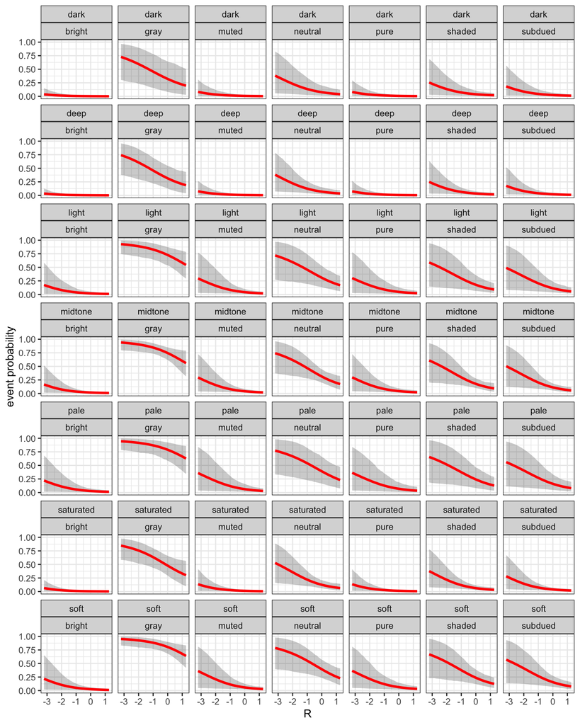

```r
set.seed(0)
post_pred_summary_06_R %>%
  left_join(viz_grid_R %>% tibble::rowid_to_column('pred_id'),
            by = 'pred_id') %>%
  ggplot(mapping = aes(x = R)) +
  geom_ribbon(mapping = aes(ymin = mu_q05, ymax = mu_q95), alpha = 0.25) +
  geom_line(mapping = aes(y = mu_avg), linewidth = 1.15, color = "red") +
  facet_wrap( ~ Lightness * Saturation) +
  labs(y = "event probability", scales = "free_y") +
  theme_bw()
```

For G:

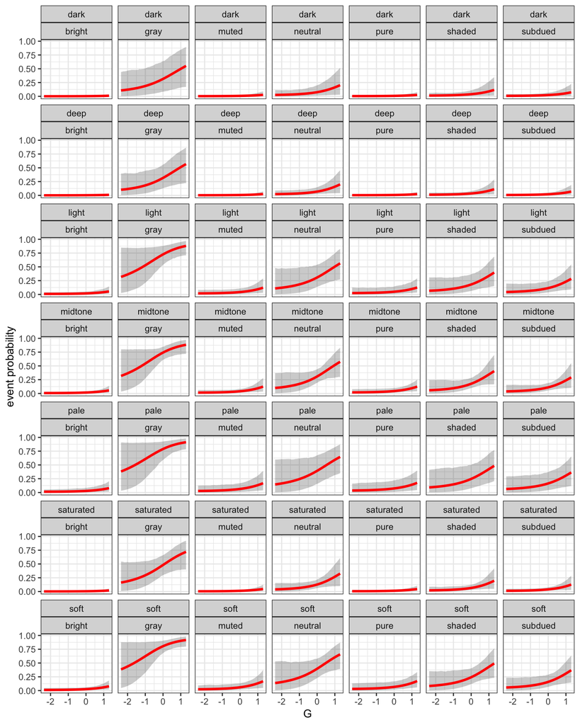

```r
set.seed(0)
post_pred_summary_06_G %>%
  left_join(viz_grid_G %>% tibble::rowid_to_column('pred_id'),
            by = 'pred_id') %>%
  ggplot(mapping = aes(x = G)) +
  geom_ribbon(mapping = aes(ymin = mu_q05, ymax = mu_q95), alpha = 0.25) +
  geom_line(mapping = aes(y = mu_avg), linewidth = 1.15, color = "red") +
  facet_wrap( ~ Lightness * Saturation) +
  labs(y = "event probability", scales = "free_y") +
  theme_bw()
```

For B:

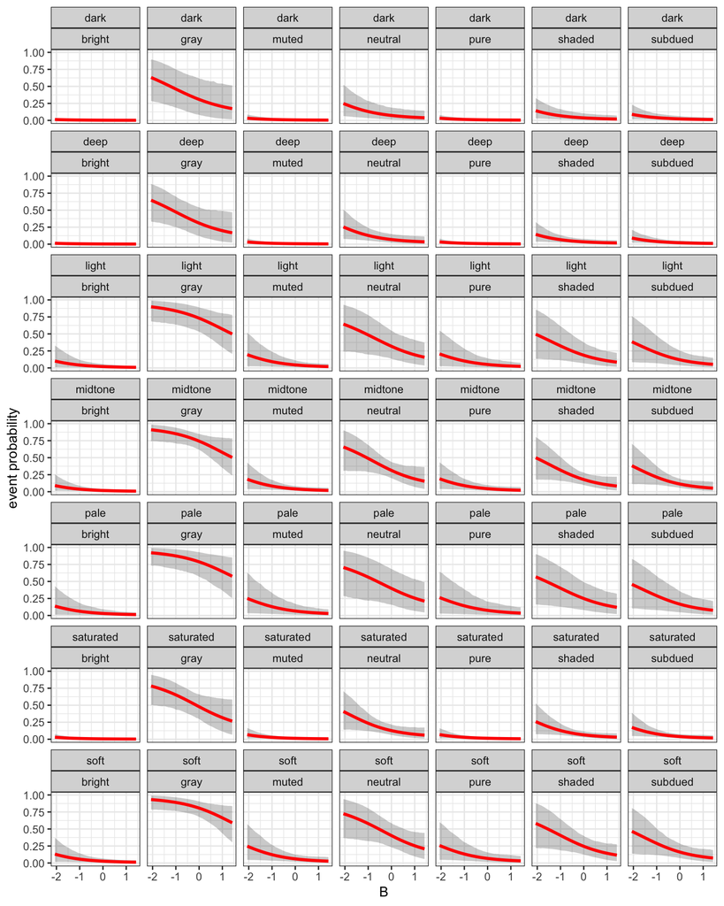

```r
set.seed(0)
post_pred_summary_06_B %>%
  left_join(viz_grid_B %>% tibble::rowid_to_column('pred_id'),
            by = 'pred_id') %>%
  ggplot(mapping = aes(x = B)) +
  geom_ribbon(mapping = aes(ymin = mu_q05, ymax = mu_q95), alpha = 0.25) +
  geom_line(mapping = aes(y = mu_avg), linewidth = 1.15, color = "red") +
  facet_wrap( ~ Lightness * Saturation) +
  labs(y = "event probability", scales = "free_y") +
  theme_bw()
```

For Hue:

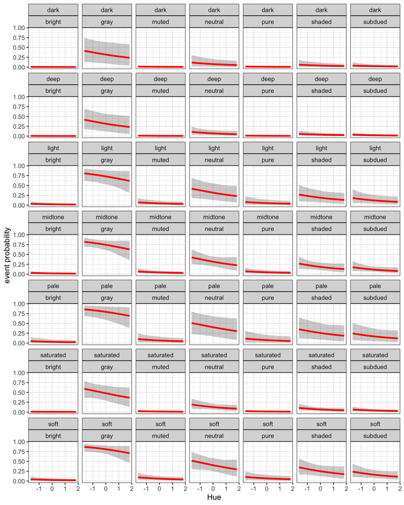

```r
set.seed(0)
post_pred_summary_06_H %>%
  left_join(viz_grid_H %>% tibble::rowid_to_column('pred_id'),
            by = 'pred_id') %>%
  ggplot(mapping = aes(x = Hue)) +
  geom_ribbon(mapping = aes(ymin = mu_q05, ymax = mu_q95), alpha = 0.25) +
  geom_line(mapping = aes(y = mu_avg), linewidth = 1.15, color = "red") +
  facet_wrap( ~ Lightness * Saturation) +
  labs(y = "event probability", scales = "free_y") +
  theme_bw()
```

# 6. Train/Tune with Resampling

## 6.1 Model Declaration

To train and tune more complex model with resampling, we first specify the resampling scheme to be 10 fold with 3 repeats. The primary performance metric will be “Accuracy”. We use caret to train and tune the models. Here, we prepare the data same as in Part 1 and perform normalization on continuous inputs:

```r
df_orig <- read_csv(here("Final project/paint_project_train_data.csv"))
df_caret <- df_orig %>%
  mutate(outcome = ifelse(outcome == 1, 'event', 'non_event'),
         outcome = factor(outcome, levels = c('event', 'non_event'))) %>%
  select(R, G, B, Lightness, Saturation, Hue, outcome) %>%
  mutate_at(c("R", "G", "B", "Hue"), ~(scale(.) %>% as.vector))

df_caret %>% summary()
```

```
##        R                 G                 B            Lightness
##  Min.   :-3.1976   Min.   :-2.3620   Min.   :-2.0739   Length:835
##  1st Qu.:-0.6339   1st Qu.:-0.7650   1st Qu.:-0.8753   Class :character
##  Median : 0.3427   Median : 0.2331   Median : 0.1770   Mode  :character
##  Mean   : 0.0000   Mean   : 0.0000   Mean   : 0.0000
##  3rd Qu.: 0.8049   3rd Qu.: 0.9118   3rd Qu.: 0.9273
##  Max.   : 1.2496   Max.   : 1.2910   Max.   : 1.4215
##   Saturation             Hue                outcome
##  Length:835         Min.   :-1.65200   event    :191
##  Class :character   1st Qu.:-0.85952   non_event:644
##  Mode  :character   Median :-0.06703
##                     Mean   : 0.00000
##                     3rd Qu.: 0.82452
##                     Max.   : 1.81513
```

```r
set.seed(0)
my_ctrl <- trainControl(method = "repeatedcv", number = 10, repeats = 3)
my_metric <- 'Accuracy'
```

Here, we define the models to be trained and tuned. For the linear models, it is defined as below, we include the suppress warnings code to ignore the warning message discussed in Section 3:

```r
set.seed(0)
glm_grid = expand.grid(parameter=c(0.001, 0.01, 0.1, 1,10,100, 1000))

suppressWarnings({

glm_04 <- train(outcome ~ R + G + B + Hue + Lightness + Saturation,
                data = df_caret,
                method = "glm",
                metric = my_metric,
                preProcess = c("center", "scale"),
                trControl = my_ctrl,
                tuneGrid = glm_grid) # All categorical and continuous variables

glm_05 <- train(outcome ~ (R + G + B + Hue) * (Lightness + Saturation),
                data = df_caret,
                method = "glm",
                metric = my_metric,
                preProcess = c("center", "scale"),
                trControl = my_ctrl,
                tuneGrid = glm_grid) # Interaction of categorical inputs with continuous inputs main effects

glm_06 <- train(outcome ~ (R + G + B + Hue)^2 + Lightness + Saturation,
                data = df_caret,
                method = "glm",
                metric = my_metric,
                preProcess = c("center", "scale"),
                trControl = my_ctrl,
                tuneGrid = glm_grid) # Categorical inputs, main effect and all pairwise interactions

glm_09 <- train(outcome ~ (R + G + B)^2 * splines::ns(Hue, 2) + (Lightness + Saturation),
                data = df_caret,
                method = "glm",
                metric = my_metric,
                preProcess = c("center", "scale"),
                trControl = my_ctrl,
                tuneGrid = glm_grid)

})
```

For Elastic net models, we use the provided functions for training and tuning:

```r
set.seed(0)
enet_06_default <- train(outcome ~ (R + G + B + Hue)^2 + Lightness + Saturation,
                         data = df_caret,
                         method = "glmnet",
                         metric = my_metric,
                         preProcess = c("center", "scale"),
                         trControl = my_ctrl)
enet_06_default
```

```
## glmnet
##
## 835 samples
##   6 predictor
##   2 classes: 'event', 'non_event'
##
## Pre-processing: centered (22), scaled (22)
## Resampling: Cross-Validated (10 fold, repeated 3 times)
## Summary of sample sizes: 752, 751, 751, 752, 752, 751, ...
## Resampling results across tuning parameters:
##
##   alpha  lambda        Accuracy   Kappa
##   0.10   0.0003523518  0.8140334  0.3843901
##   0.10   0.0035235183  0.8200287  0.3918956
##   0.10   0.0352351830  0.8232129  0.3735472
##   0.55   0.0003523518  0.8140334  0.3843901
##   0.55   0.0035235183  0.8192256  0.3870462
##   0.55   0.0352351830  0.8224049  0.3668740
##   1.00   0.0003523518  0.8140334  0.3843901
##   1.00   0.0035235183  0.8196082  0.3857061
##   1.00   0.0352351830  0.8228065  0.3679188
##
## Accuracy was used to select the optimal model using the largest value.
## The final values used for the model were alpha = 0.1 and lambda = 0.03523518.
```

```r
set.seed(0)
enet_09_default <- train(outcome ~ (R + G + B)^2 * splines::ns(Hue, 2) + (Lightness + Saturation),
                         data = df_caret,
                         method = "glmnet",
                         metric = my_metric,
                         preProcess = c("center", "scale"),
                         trControl = my_ctrl)
enet_09_default
```

```
## glmnet
##
## 835 samples
##   6 predictor
##   2 classes: 'event', 'non_event'
##
## Pre-processing: centered (32), scaled (32)
## Resampling: Cross-Validated (10 fold, repeated 3 times)
## Summary of sample sizes: 752, 751, 751, 752, 752, 751, ...
## Resampling results across tuning parameters:
##
##   alpha  lambda        Accuracy   Kappa
##   0.10   0.0003523518  0.8428438  0.5119253
##   0.10   0.0035235183  0.8320242  0.4497251
##   0.10   0.0352351830  0.8112315  0.3403563
##   0.55   0.0003523518  0.8424421  0.5112841
##   0.55   0.0035235183  0.8332148  0.4543627
##   0.55   0.0352351830  0.8196174  0.3633795
##   1.00   0.0003523518  0.8468217  0.5241923
##   1.00   0.0035235183  0.8304130  0.4450971
##   1.00   0.0352351830  0.8212096  0.3640658
##
## Accuracy was used to select the optimal model using the largest value.
## The final values used for the model were alpha = 1 and lambda = 0.0003523518.
```

From the results, we define the tuning grid(s):

```r
set.seed(0)
enet_06_grid <- expand.grid(alpha = seq(0.1, 1.0, length.out = 9),
                            lambda = exp(seq(log(min(enet_06_default$results$lambda)),
                            log(max(enet_06_default$results$lambda)),
                            length.out = 25)))


enet_09_grid <- expand.grid(alpha = seq(0.1, 1.0, length.out = 9),
                            lambda = exp(seq(log(min(enet_09_default$results$lambda)),
                            log(max(enet_09_default$results$lambda)),
                            length.out = 25)))
```

Here, we tune the Elastic Net models. For Enet_06:

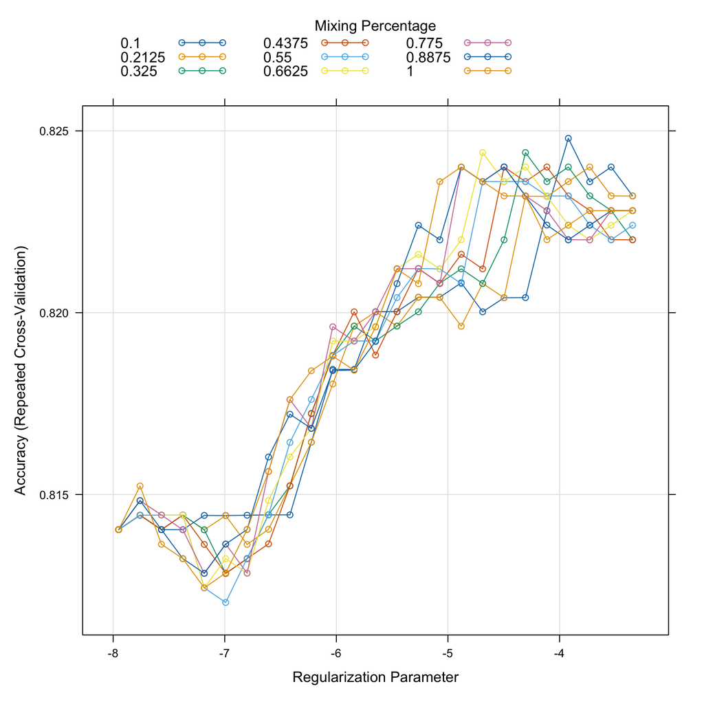

```r
set.seed(0)
enet_06_tune <- train(outcome ~ (R + G + B + Hue)^2 + Lightness + Saturation,
                      data = df_caret,
                      method = "glmnet",
                      metric = my_metric,
                      preProcess = c("center", "scale"),
                      trControl = my_ctrl,
                      tuneGrid = enet_06_grid)
enet_06_tune %>% plot(xTrans = log)
```

For Enet_09:

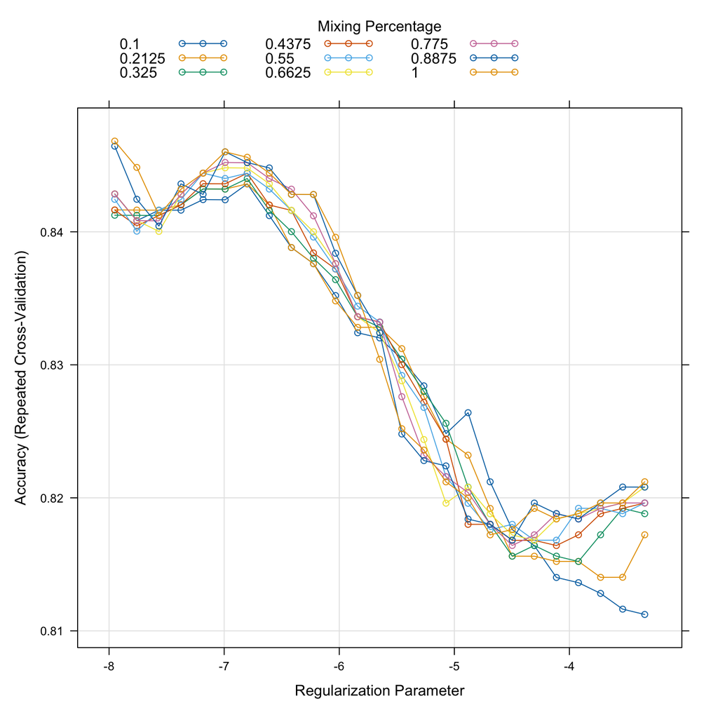

```r
set.seed(0)
enet_09_tune <- train(outcome ~ (R + G + B)^2 * splines::ns(Hue, 2) + (Lightness + Saturation),
                      data = df_caret,
                      method = "glmnet",
                      metric = my_metric,
                      preProcess = c("center", "scale"),
                      trControl = my_ctrl,
                      tuneGrid = enet_09_grid)
enet_09_tune %>% plot(xTrans = log)
```

For the Neural Network and the tuning process:

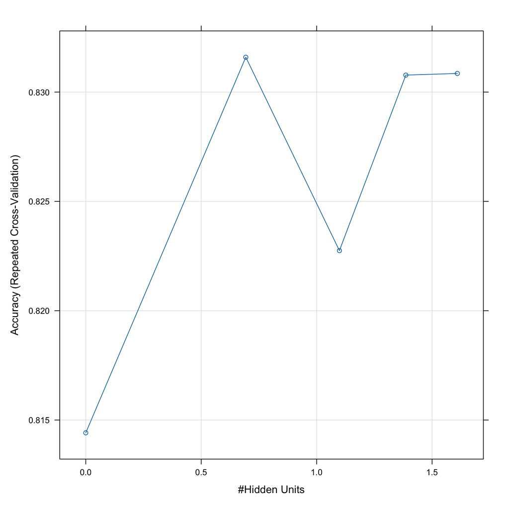

```r
set.seed(0)
nnet_grid <- expand.grid(size = seq(1, 5, 1),
                         decay = seq(0.1, 1, 10))

nnet_tune <- train(outcome ~ .,
                   data = df_caret,
                   method = 'nnet',
                   metric = my_metric,
                   preProcess = c('center', 'scale'),
                   trControl = my_ctrl,
                   trace = FALSE,
                   tuneGrid = nnet_grid)
nnet_tune %>% plot(xTrans = log)
```

For the Random Forest: and the tuning process:

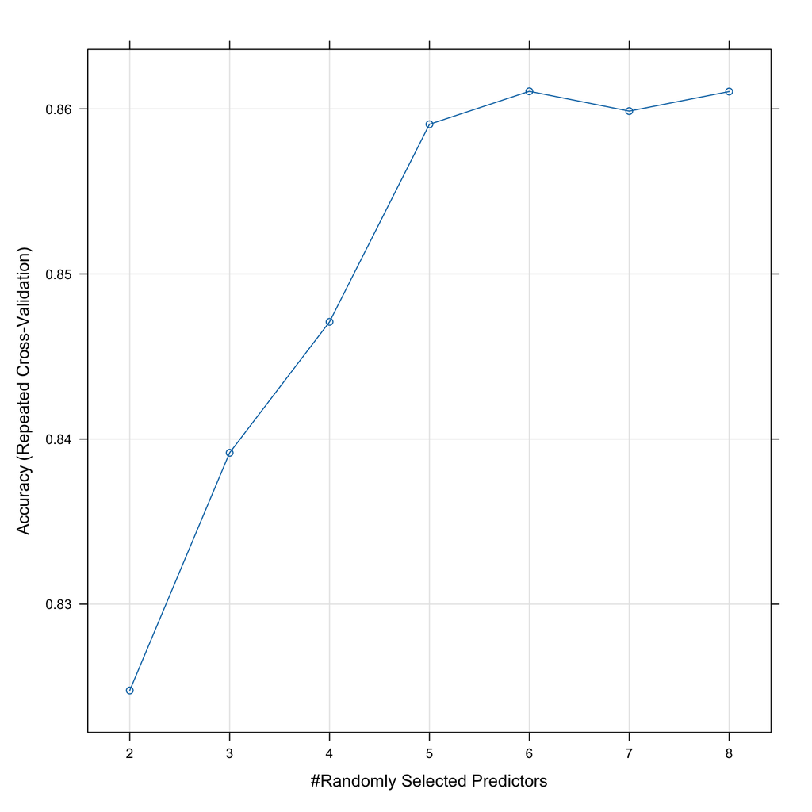

```r
set.seed(0)
rf_grid <- expand.grid(mtry = seq(2, 8, by = 1))

rf_tune <- train(outcome ~ .,
                 data = df_caret,
                 method = 'rf',
                 metric = my_metric,
                 preProcess = c('center', 'scale'),
                 trControl = my_ctrl,
                 trace = FALSE,
                 importance = TRUE,
                 tuneGrid = rf_grid,
                 linout = TRUE)
plot(rf_tune)
```

For the Gradient boosted tree and the tuning process:

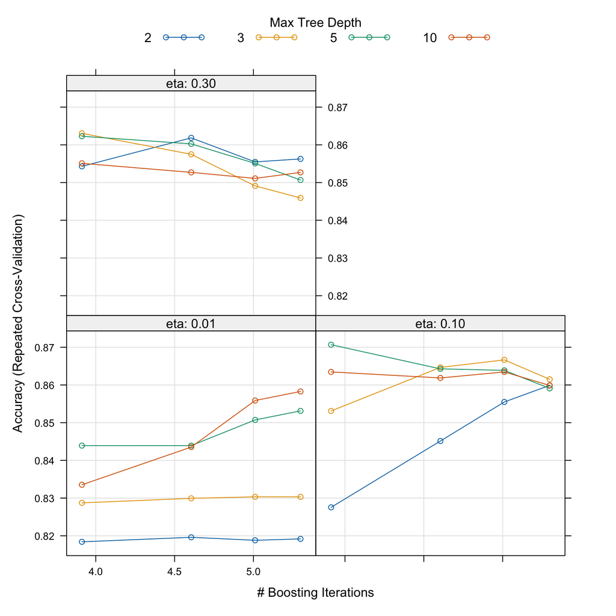

```r
set.seed(0)
xgb_grid <- expand.grid(nrounds = c(50, 100, 150, 200),
                        max_depth = c(2, 3, 5, 10),
                        eta = c(0.01, 0.1, 0.3),
                        gamma = c(0),
                        colsample_bytree = 1,
                        min_child_weight = 1,
                        subsample = 1
                        )

xgb_tune <- train(outcome ~ .,
                  data = df_caret,
                  method = 'xgbTree',
                  metric = my_metric,
                  trControl = my_ctrl,
                  preProcess = c("center", "scale"),
                  verbosity = 0,
                  nthread = 1,
                  tuneGrid = xgb_grid)
xgb_tune %>% plot(xTrans = log)
```

Here, we also include (1) Support Vector Machine (SVM) and (2) K-Nearest Neighbors models:

For SVM:

```r
set.seed(0)
svm_default <- train(outcome ~ .,
                     data = df_caret,
                     method = "svmRadial",
                     metric = my_metric,
                     preProcess = c("center", "scale"),
                     trControl = my_ctrl)
svm_default
```

```
## Support Vector Machines with Radial Basis Function Kernel
##
## 835 samples
##   6 predictor
##   2 classes: 'event', 'non_event'
##
## Pre-processing: centered (16), scaled (16)
## Resampling: Cross-Validated (10 fold, repeated 3 times)
## Summary of sample sizes: 752, 751, 751, 752, 752, 751, ...
## Resampling results across tuning parameters:
##
##   C     Accuracy   Kappa
##   0.25  0.8228065  0.3679188
##   0.50  0.8228065  0.3679188
##   1.00  0.8228065  0.3679188
##
## Tuning parameter 'sigma' was held constant at a value of 0.03884864
## Accuracy was used to select the optimal model using the largest value.
## The final values used for the model were sigma = 0.03884864 and C = 0.25.
```

The tuning process:

```r
set.seed(0)
svm_grid <- expand.grid(sigma = c(svm_default$bestTune$sigma),
                        C = c(0.25, 0.5, 0.75, 1))

svm_tune <- train(outcome ~ .,
                  data = df_caret,
                  method = "svmRadial",
                  metric = my_metric,
                  preProcess = c("center", "scale"),
                  trControl = my_ctrl,
                  tuneGrid = svm_grid)
```

For KNN and the tuning process:

```r
set.seed(0)
knn_grid <- expand.grid(k = seq(1, 10, by = 1))

knn_tune <- train(outcome ~ .,
                  data = df_caret,
                  method = "knn",
                  metric = my_metric,
                  preProcess = c("center", "scale"),
                  trControl = my_ctrl,
                  tuneGrid = knn_grid)
```

## 6.2 Model Comparisan

Here, we compare the models we have trained and tuned:

```r
set.seed(0)
caret_acc_compare <- resamples(list(glm_04 = glm_04,
                                    glm_05 = glm_05,
                                    glm_06 = glm_06,
                                    glm_09 = glm_09,
                                    ENET_06 = enet_06_tune,
                                    ENET_09 = enet_09_tune,
                                    NNET = nnet_tune,
                                    RF = rf_tune,
                                    XGB = xgb_tune,
                                    SVM = svm_tune,
                                    KNN = knn_tune))
```

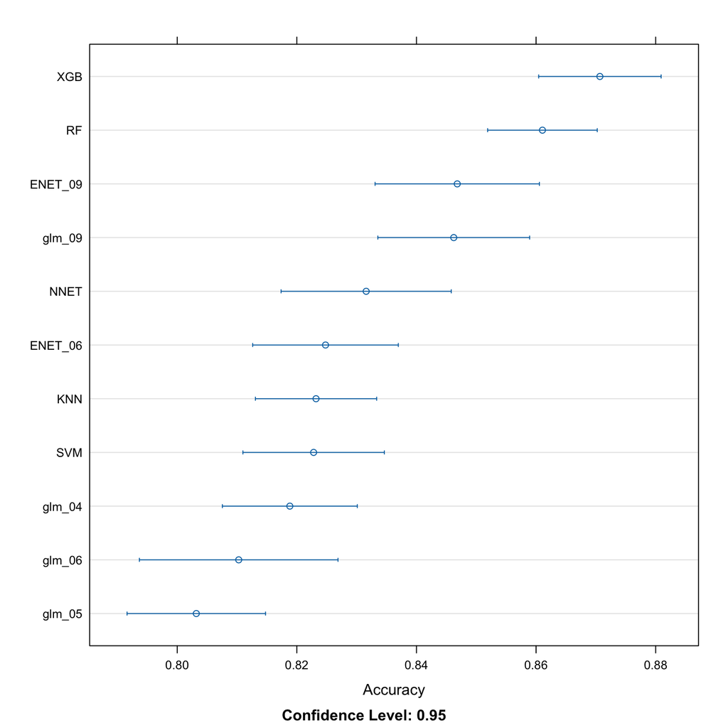

```r
dotplot(caret_acc_compare, metric = 'Accuracy')
```

Thus, we show that the Gradient Boost Tree is the best model. We save the identified best model as “class_best.rds”:

```r
xgb_tune %>%  readr::write_rds(here("Final project/Submit/class_best.rds"))
```